# StockX

## By Release Month

```r
# Mean profit by release month
group.rmonth <- df.new  %>%
                    mutate(month = format(`Release Date`, "%m")) %>%
                    group_by(month, Brand) %>%
                    dplyr::summarize(count = n(),mean_profit = round(mean(profit),2))
# Display table
DT::datatable(group.rmonth, caption = "Count and mean profit by release month")
```

|  | month | Brand | count | mean_profit |
| --- | --- | --- | --- | --- |
| 1 | 02 | Off-White | 1371 | 383.2 |
| 2 | 02 | Yeezy | 11201 | 186.6 |
| 3 | 03 | Off-White | 1626 | 620.56 |
| 4 | 04 | Off-White | 1591 | 342.02 |
| 5 | 04 | Yeezy | 9097 | 68.71 |
| 6 | 06 | Off-White | 5936 | 542.48 |
| 7 | 06 | Yeezy | 11491 | 57.35 |
| 8 | 07 | Off-White | 1884 | 570.47 |
| 9 | 08 | Off-White | 2387 | 516.92 |
| 10 | 08 | Yeezy | 95 | 695.09 |

[output cut: 7 more lines]

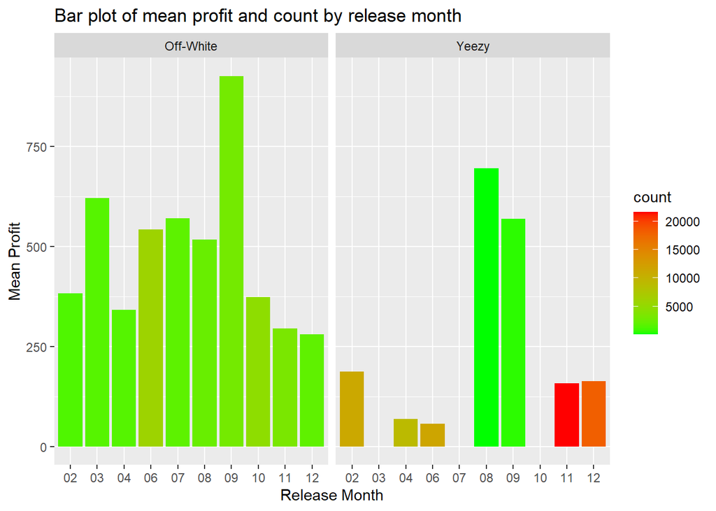

```r
# Make graph
p<- ggplot(group.rmonth, aes(x = month, y = mean_profit, fill = count)) +
  geom_bar(stat = "identity") +
  xlab("Release Month") +
  ylab("Mean Profit") +
  ggtitle("Bar plot of mean profit and count by release month") +
  scale_fill_gradient(low = "green", high = "red")+
  facet_wrap(~Brand)

p
```

```r
# save plot
ggsave("StockX_relation_btw_profit_rmonth.png", plot = p, width = 5, height = 3, dpi = 300)
```

## By Size

```r
# Mean profit by size
group.shoesize <- df.new  %>%
                    group_by(`Shoe Size`, Brand) %>%
                    dplyr::summarize(count = n(),mean_profit = round(mean(profit),2))
# Display table
DT::datatable(group.shoesize, caption = "Count and mean profit by size")
```

|  | Shoe Size | Brand | count | mean_profit |
| --- | --- | --- | --- | --- |
| 1 | 3.5 | Off-White | 3 | 305.33 |
| 2 | 3.5 | Yeezy | 1 | 129 |
| 3 | 4 | Off-White | 471 | 407.49 |
| 4 | 4 | Yeezy | 1770 | 107.99 |
| 5 | 4.5 | Off-White | 288 | 416.85 |
| 6 | 4.5 | Yeezy | 1016 | 114.21 |
| 7 | 5 | Off-White | 544 | 438.12 |
| 8 | 5 | Yeezy | 3033 | 123.89 |
| 9 | 5.5 | Off-White | 287 | 403.33 |
| 10 | 5.5 | Yeezy | 2334 | 127.12 |

[output cut: 39 more lines]

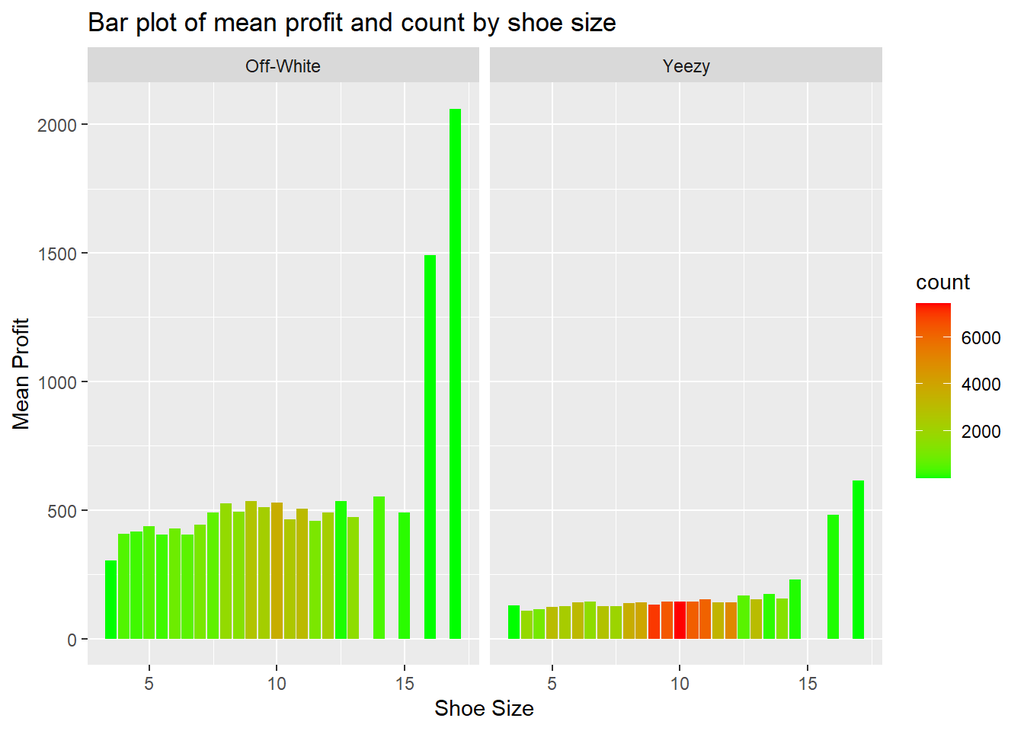

```r
# Make graph
p<-ggplot(group.shoesize, aes(x = `Shoe Size`, y = mean_profit, fill = count)) +
  geom_bar(stat = "identity") +
  xlab("Shoe Size") +
  ylab("Mean Profit") +
  ggtitle("Bar plot of mean profit and count by shoe size") +
  scale_fill_gradient(low = "green", high = "red") +
  facet_wrap(~Brand)

p
```

```r
# save plot
ggsave("StockX_relation_btw_profit_size.png", plot = p, width = 5, height = 3, dpi = 300)
```

## By Number of Weeks to Keep

Most transactions occur right after the shoe is released. This is because everybody wants the new shoe when it comes out. As a result, most sales happen between 0 and 2 weeks within the release date.

```r
group.weeks <- df.new  %>%
                    group_by(weeks2keep, Brand) %>%
                    dplyr::summarize(count = n(),mean_profit = round(mean(profit),2))
# Display table
DT::datatable(group.weeks, caption = "Count and mean profit by weeks to keep")
```

|  | weeks2keep | Brand | count | mean_profit |
| --- | --- | --- | --- | --- |
| 1 | -10 | Off-White | 1 | 1340 |
| 2 | -9 | Off-White | 1 | 1340 |
| 3 | -8 | Off-White | 11 | 657.73 |
| 4 | -8 | Yeezy | 1 | 160 |
| 5 | -7 | Off-White | 11 | 838.27 |
| 6 | -7 | Yeezy | 1 | 230 |
| 7 | -6 | Off-White | 24 | 663.79 |
| 8 | -5 | Off-White | 16 | 1071.12 |
| 9 | -4 | Off-White | 667 | 864.29 |
| 10 | -4 | Yeezy | 1 | 1605 |

[output cut: 268 more lines]

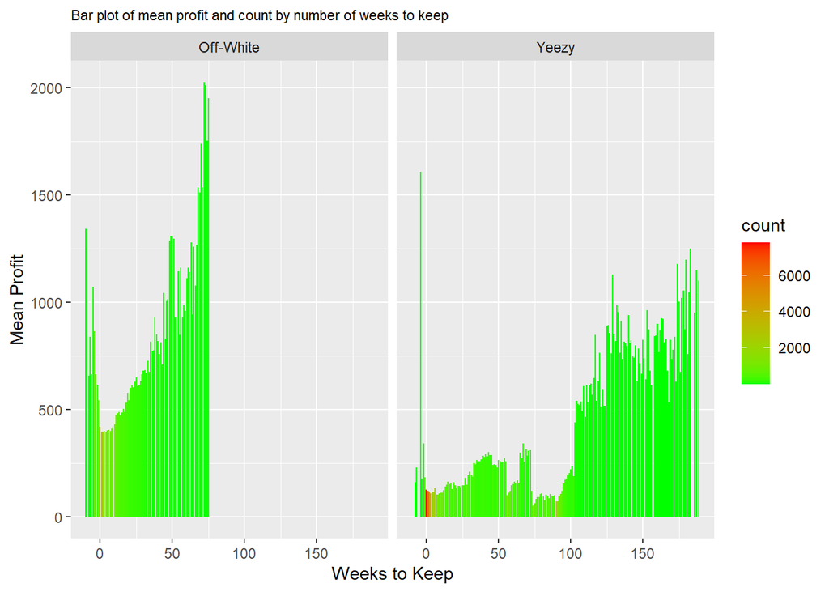

```r
# plot the relationship between weeks2keep and profit
p<-ggplot(group.weeks, aes(x = weeks2keep, y = mean_profit, fill = count)) +
  geom_bar(stat = "identity") +
  xlab("Weeks to Keep") +
  ylab("Mean Profit") +
  ggtitle("Bar plot of mean profit and count by number of weeks to keep") +
  scale_fill_gradient(low = "green", high = "red") +
  facet_wrap(~Brand) +
  theme(plot.title = element_text(size = rel(0.8)))

p
```

```r
# save plot
ggsave("StockX_relation_btw_profit_weeks.png", plot = p, width = 5, height = 3, dpi = 300)
```

## Relationship Between Profit and Number of Days to Keep Sneakers

The graph mostly supports the idea that the longer shoe is kept, the more profit is generated. The line of best fit has a positive slope, showing that the longer a shoe is kept, the more profit is generated. Of course this is not always the case, but generally speaking, Yeezys and Off-Whites appreciate over time.

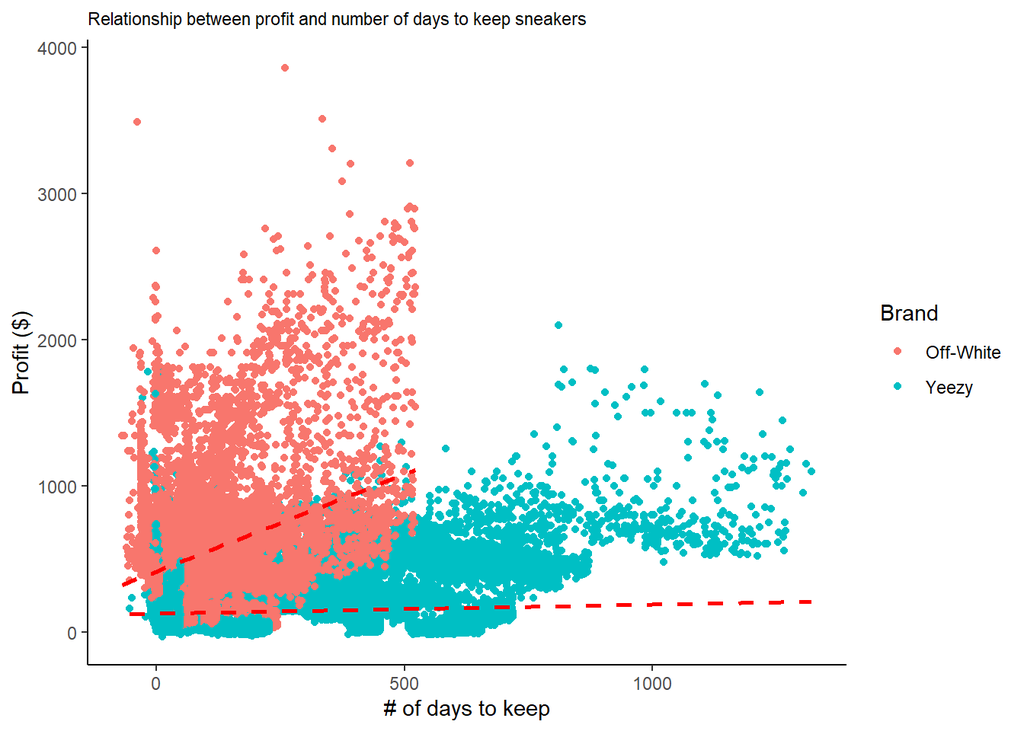

```r
# plot the relationship between days2keep and profit
p<- ggplot(data = df.new, aes(y = profit, x = days2keep, group=Brand, color=Brand)) +
  geom_point() +
  ggtitle("Relationship between profit and number of days to keep sneakers ") +
  geom_smooth(method = "lm", se = FALSE, color = "red", linetype = "dashed") +
  ylab("Profit ($)") +
  xlab("# of days to keep") +
  theme_classic()+
  theme(plot.title = element_text(size = rel(0.8)))

p
```

```r
# save plot
ggsave("StockX_relation_btw_profit_days.png", plot = p, width = 5, height = 3, dpi = 300)
```

## What factors affect profits?

This graph shows bi-relationships between the factors. Blue means a positive relationship, while orange means a negative relationship. In addition, circle size shows the magnitude of the relationship. A great profit is associated with a great sale price and a low retail price. But it seems not related to shoe size and time to keep.

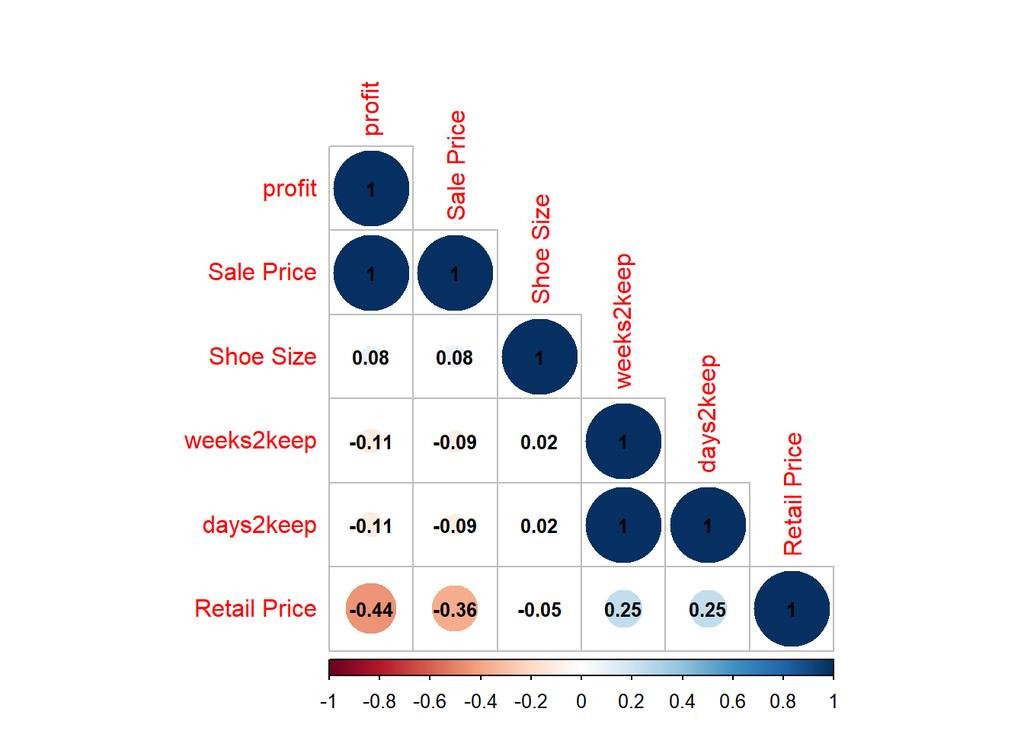

```r
df.num <- select_if(df.new, is.numeric)
M = cor(df.num)

corrplot(M, method = 'circle', addCoef.col ='black', number.cex = 0.8, order = 'AOE', type = 'lower', diag = TRUE)
```

```r
# save plot
png(height=1200, width=1200, pointsize=25, file="StockX_relation_btw_profit_allfactor.png")
corrplot(M, method = 'circle', addCoef.col ='black', number.cex = 0.8, order = 'AOE', type = 'lower', diag = TRUE)

dev.off()
```